# Annual Fund $10K Model Data Exploration

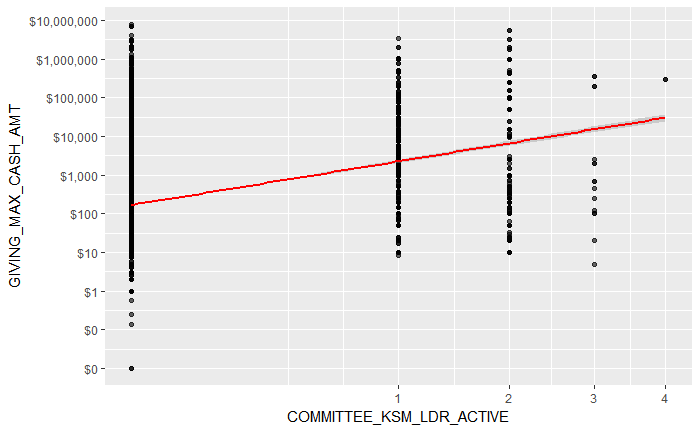

```r
scatterplotter('COMMITTEE_KSM_LDR_ACTIVE') +
  scale_x_sqrt()
```

Nonmonontonic relationship; does that make sense? Artifact? **EXCLUDE**

```r
summary2(full.data$KSM_EVENTS_ATTENDED %>% sqrt())
```

```
     Min.   1st Qu.    Median      Mean   3rd Qu.      Max.     StDev Skewnewss  Kurtosis
    0.000     0.000     0.000     0.397     1.000     7.810     0.771     2.210     5.980
```

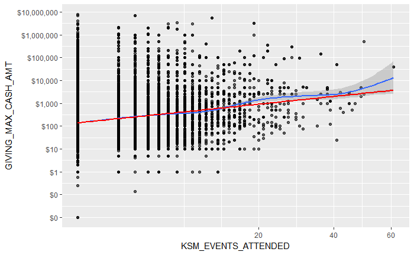

```r
scatterplotter('KSM_EVENTS_ATTENDED') +
  scale_x_sqrt()
```

Looks ok.

```r
summary2(full.data$KSM_EVENTS_YRS %>% sqrt())
```

```
     Min.   1st Qu.    Median      Mean   3rd Qu.      Max.     StDev Skewnewss  Kurtosis
    0.000     0.000     0.000     0.347     1.000     3.320     0.633     1.590     1.340
```

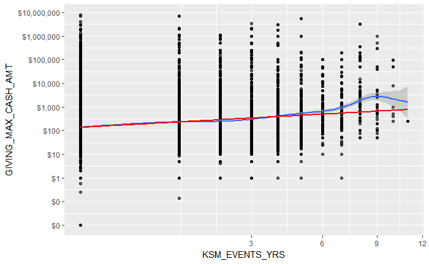

```r
scatterplotter('KSM_EVENTS_YRS') +
  scale_x_sqrt()
```

Looks ok.

```r
summary2(full.data$KSM_EVENTS_PREV_3_FY %>% sqrt())
```

```
     Min.   1st Qu.    Median      Mean   3rd Qu.      Max.     StDev Skewnewss  Kurtosis
    0.000     0.000     0.000     0.247     0.000     6.160     0.595     2.770     9.080
```

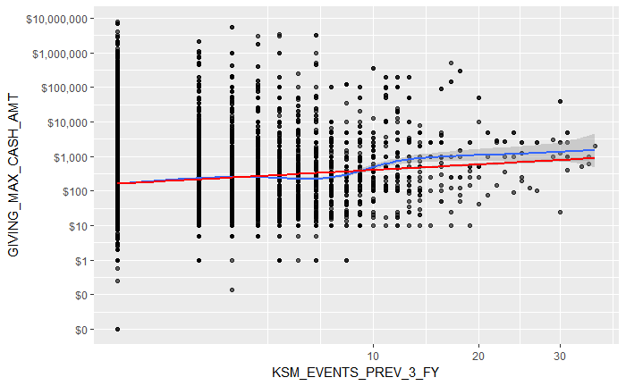

```r
scatterplotter('KSM_EVENTS_PREV_3_FY') +
  scale_x_sqrt()
```

Looks ok.

```r
summary2(full.data$KSM_EVENTS_REUNIONS %>% sqrt())
```

```
     Min.   1st Qu.    Median      Mean   3rd Qu.      Max.     StDev Skewnewss  Kurtosis
    0.000     0.000     0.000     0.165     0.000     2.450     0.416     2.300     3.840
```

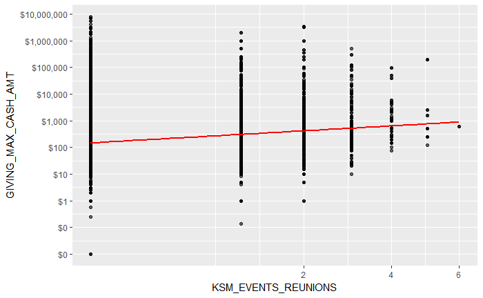

```r
scatterplotter('KSM_EVENTS_REUNIONS') +
  scale_x_sqrt()
```

Looks ok, but could also work as an indicator; how many people have really gone to 4+? **Consider additional transformation**

```r
summary2(full.data$KSM_SPEAKER_YEARS %>% sqrt())
```

```
     Min.   1st Qu.    Median      Mean   3rd Qu.      Max.     StDev Skewnewss  Kurtosis
 0.00e+00  0.00e+00  0.00e+00  4.31e-03  0.00e+00  1.41e+00  6.56e-02  1.52e+01  2.29e+02
```

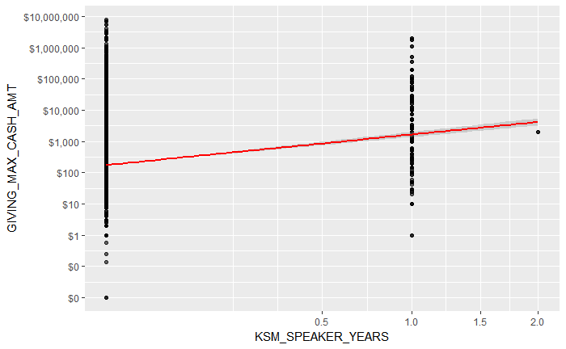

```r
scatterplotter('KSM_SPEAKER_YEARS') +
  scale_x_sqrt()
```

Just started tracking. Good candidate for binary indicator. **Consider additional transformation**

```r
summary2(full.data$KSM_SPEAKER_TIMES %>% sqrt())
```

```
     Min.   1st Qu.    Median      Mean   3rd Qu.      Max.     StDev Skewnewss  Kurtosis
 0.00e+00  0.00e+00  0.00e+00  6.35e-03  0.00e+00  2.83e+00  1.05e-01  1.92e+01  4.09e+02
```

```r
summary(full.data$KSM_SPEAKER_TIMES %>% factor())
```

```
    0     1     2     3     4     8
92804   232    23     3    99    44
```

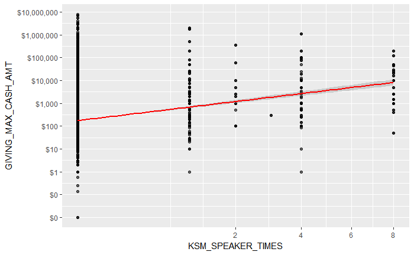

```r
scatterplotter('KSM_SPEAKER_TIMES') +
  scale_x_sqrt()
```

Good candidate for binary indicator, though that’s duplicative with the above. **Consider additional transformation**

```r
summary2(full.data$KSM_FEATURED_COMM_YEARS %>% sqrt())
```

```
     Min.   1st Qu.    Median      Mean   3rd Qu.      Max.     StDev Skewnewss  Kurtosis
 0.00e+00  0.00e+00  0.00e+00  3.06e-03  0.00e+00  1.73e+00  5.71e-02  1.91e+01  3.73e+02
```

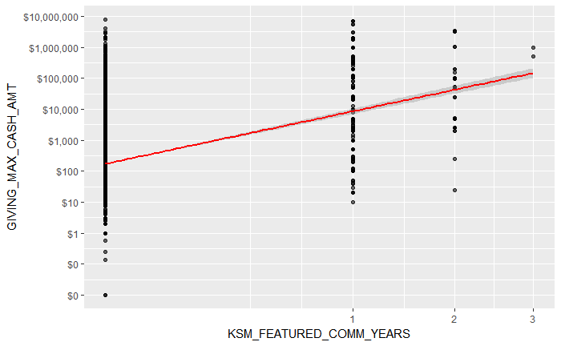

```r
scatterplotter('KSM_FEATURED_COMM_YEARS') +
  scale_x_sqrt()
```

Good candidate for binary indicator. **Consider additional transformation**

```r
summary2(full.data$KSM_FEATURED_COMM_TIMES %>% sqrt())
```

```
     Min.   1st Qu.    Median      Mean   3rd Qu.      Max.     StDev Skewnewss  Kurtosis
 0.00e+00  0.00e+00  0.00e+00  3.12e-03  0.00e+00  2.00e+00  5.88e-02  1.96e+01  4.05e+02
```

```r
summary(full.data$KSM_FEATURED_COMM_TIMES %>% factor())
```

```
    0     1     2     3     4
92934   231    32     4     4
```

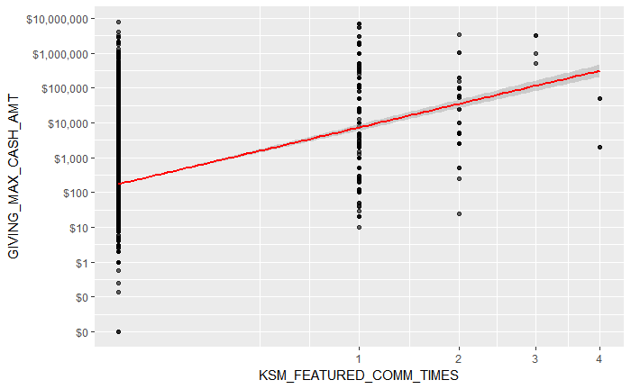

```r
scatterplotter('KSM_FEATURED_COMM_TIMES') +
  scale_x_sqrt()
```

Good candidate for binary indicator, though that’s duplicative with the above. **EXCLUDE**

```r
summary2(full.data$KSM_CORP_RECRUITER_YEARS %>% sqrt())
```

```
     Min.   1st Qu.    Median      Mean   3rd Qu.      Max.     StDev Skewnewss  Kurtosis
   0.0000    0.0000    0.0000    0.0047    0.0000    1.0000    0.0684   14.5000  208.0000
```

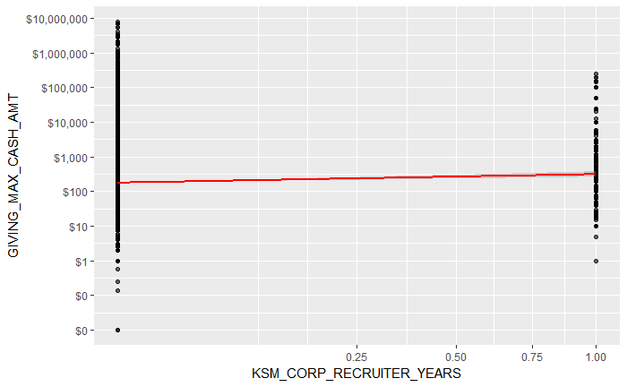

```r
scatterplotter('KSM_CORP_RECRUITER_YEARS') +
  scale_x_sqrt()
```

Looks fine; treat as binary indicator.

```r
summary2(full.data$KSM_CORP_RECRUITER_TIMES %>% sqrt())
```

```
     Min.   1st Qu.    Median      Mean   3rd Qu.      Max.     StDev Skewnewss  Kurtosis
   0.0000    0.0000    0.0000    0.0047    0.0000    1.0000    0.0684   14.5000  208.0000
```

```r
summary(full.data$KSM_CORP_RECRUITER_TIMES %>% factor())
```

```
    0     1
92767   438
```

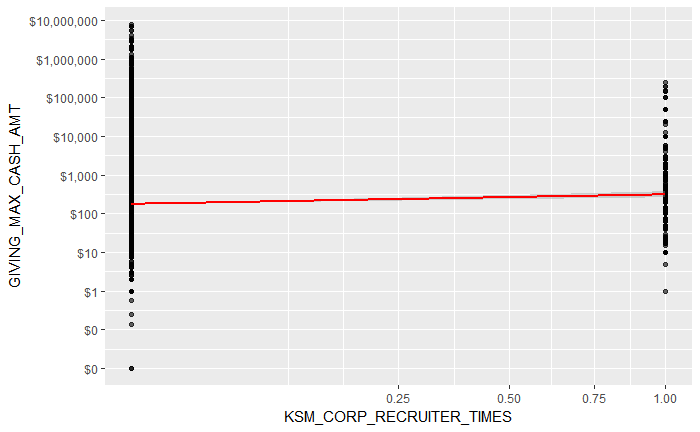

```r
scatterplotter('KSM_CORP_RECRUITER_TIMES') +
  scale_x_sqrt()
```

Duplicative with above. **EXCLUDE**

```r
summary2(full.data$ATHLETICS_TICKET_YEARS %>% sqrt())
```

```
     Min.   1st Qu.    Median      Mean   3rd Qu.      Max.     StDev Skewnewss  Kurtosis
   0.0000    0.0000    0.0000    0.0492    0.0000    3.3200    0.3440    7.6500   60.4000
```

```r
summary(full.data$ATHLETICS_TICKET_YEARS %>% factor())
```

```
    0     1     2     3     4     5     6     7     8     9    10    11
90994   594   266   155   174   107   128    58    68    58   450   153
```

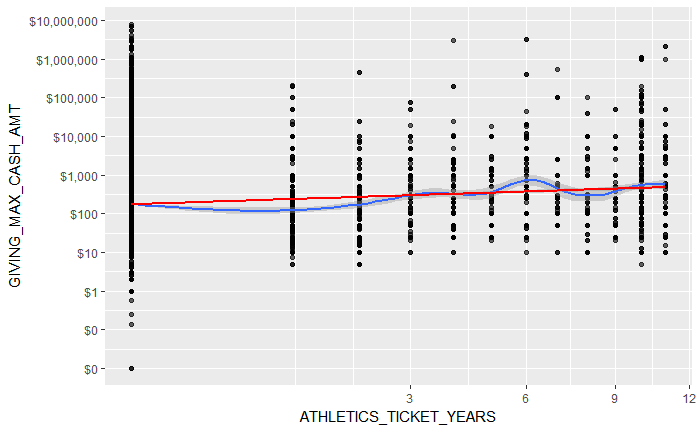

```r
scatterplotter('ATHLETICS_TICKET_YEARS') +
  scale_x_sqrt()
```

Looks fine.

```r
summary2(full.data %>% filter(ATHLETICS_TICKET_LAST > 0) %>% select(ATHLETICS_TICKET_LAST) %>%
           unlist())
```

```
     Min.   1st Qu.    Median      Mean   3rd Qu.      Max.     StDev Skewnewss  Kurtosis
 2010.000  2010.000  2020.000  2010.000  2020.000  2020.000     3.140    -1.340     0.691
```

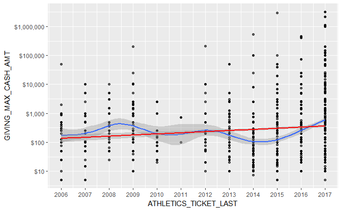

```r
scatterplotter('ATHLETICS_TICKET_LAST'
               , data = full.data %>% filter(ATHLETICS_TICKET_LAST > 0)) +
  scale_x_continuous(breaks = 2000:2050)
```

Looks fine.

## Additional exploration

### Count of cash gifts

```r
full.data %>% filter(GIFTS_CASH > 0) %>% select(GIFTS_CASH) %>%
  mutate(GIFTS_CASH = cut(GIFTS_CASH, 50)) %>% summary()
```

```
       GIFTS_CASH
 (0.695,7.1]:27137
 (7.1,13.2] : 3971
 (13.2,19.3]: 1950
 (19.3,25.4]: 1135
 (25.4,31.5]:  681
 (31.5,37.6]:  345
 (Other)    :  200
```

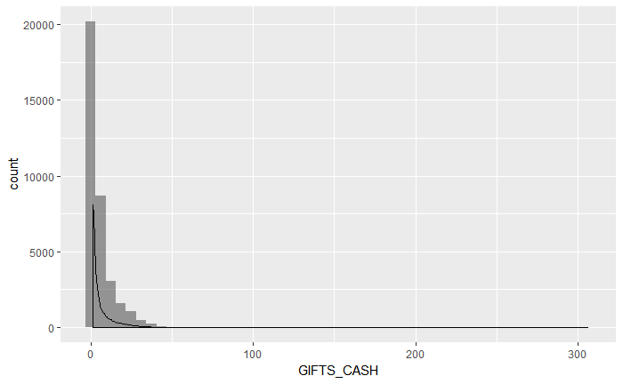

```r
histogrammer('GIFTS_CASH', data = full.data %>% filter(GIFTS_CASH > 0), m = 50)
```

Looks like around 95% of the donors have given no more than 25 cash gifts.

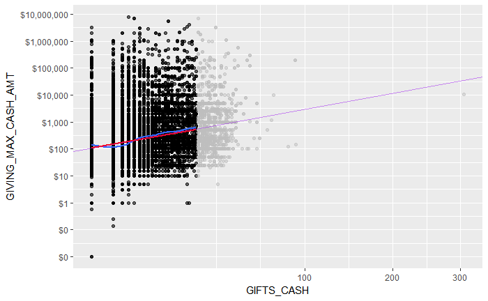

```r
# Full dataset regression line for comparison
lmtmp <- full.data %>% filter(GIVING_MAX_CASH_AMT > 0) %>%
  lm(log10(GIVING_MAX_CASH_AMT) ~ sqrt(GIFTS_CASH), data = .)
# Plot
scatterplotter('GIFTS_CASH', data = full.data %>% filter(GIFTS_CASH < 25)) +
  # Filtered data
  geom_point(aes(x = GIFTS_CASH, y = GIVING_MAX_CASH_AMT),
             data = full.data %>% filter(GIFTS_CASH >= 25),
             color = 'gray', alpha = .5) +
  scale_x_sqrt() +
  geom_abline(slope = lmtmp$coefficients[2], intercept = lmtmp$coefficients[1],
              linetype = 'solid', color = 'purple', alpha = .5)
```

```r
remove(lmtmp)
```

The red line is a linear regression for $x < 25$ (excluding gray points) while the purple line is for the full dataset. Turns out that the (relatively) extreme values really make no difference.

### Count of credit card gifts

```r
full.data %>% filter(GIFTS_CREDIT_CARD > 0) %>% select(GIFTS_CREDIT_CARD) %>%
  mutate(GIFTS_CREDIT_CARD = cut(GIFTS_CREDIT_CARD, 25)) %>% summary()
```

```
    GIFTS_CREDIT_CARD
 (0.936,3.56]:17313
 (3.56,6.12] : 3899
 (6.12,8.68] : 1136
 (8.68,11.2] :  924
 (11.2,13.8] :  397
 (13.8,16.4] :  366
 (Other)     :  473
```

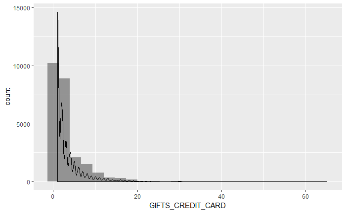

```r
histogrammer('GIFTS_CREDIT_CARD', data = full.data %>% filter(GIFTS_CREDIT_CARD > 0), m = 25)
```

```r
quantile(full.data %>% filter(GIFTS_CREDIT_CARD > 0) %>% select(GIFTS_CREDIT_CARD) %>% unlist, .9)
```

```
90%
  8
```

90th quantile is at $x = 8$.

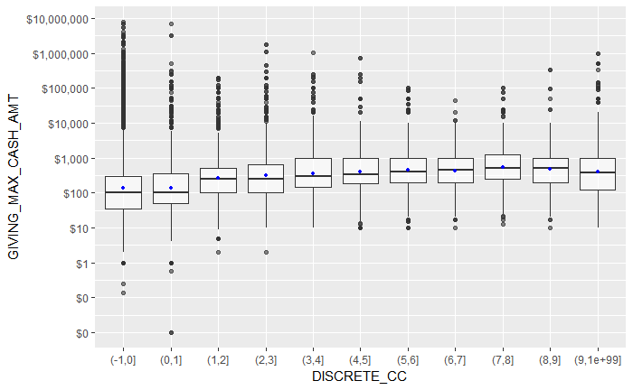

```r
full.data %>% filter(GIVING_MAX_CASH_AMT > 0) %>%
  mutate(
    DISCRETE_CC = cut(GIFTS_CREDIT_CARD, breaks = c(-1:9, 1E99))
  ) %>%
boxplotter('DISCRETE_CC', data = .) +
  stat_summary(fun.y = mean, geom = 'point', size = 1, color = 'blue')
```

Honestly seems like **discretizing into 0, 1, and 2+ would work fine.** I suspect that the dip for very high CC gift count entities is due to recurring (monthly) transactions.

### Binary candidates

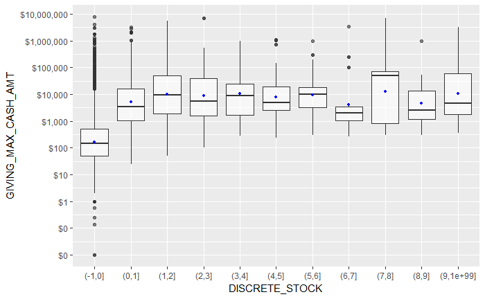

```r
full.data %>% mutate(DISCRETE_STOCK = cut(GIFTS_STOCK, c(-1:9, 1E99))) %>%
boxplotter('DISCRETE_STOCK', data = .) +
  stat_summary(fun.y = mean, geom = 'point', size = 1, color = 'blue')
```

**Treat `GIFTS_STOCK` as binary.**

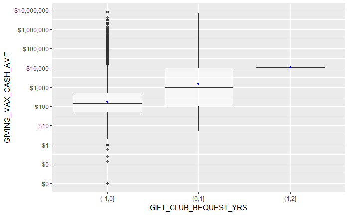

```r
full.data %>% mutate(GIFT_CLUB_BEQUEST_YRS = cut(GIFT_CLUB_BEQUEST_YRS, c(-1:2))) %>%
boxplotter('GIFT_CLUB_BEQUEST_YRS', data = .) +
  stat_summary(fun.y = mean, geom = 'point', size = 1, color = 'blue')
```

**Treat `GIFT_CLUB_BEQUEST_YRS` as binary.**

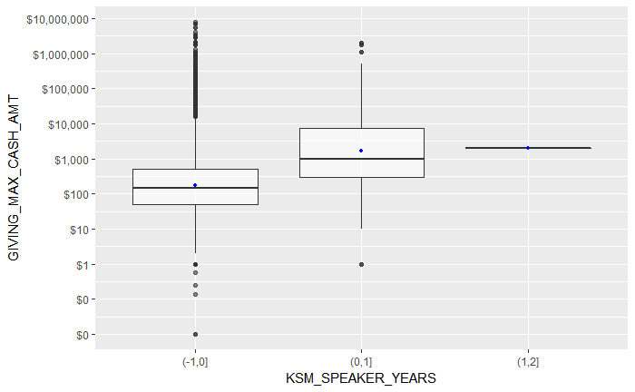

```r
full.data %>% mutate(KSM_SPEAKER_YEARS = cut(KSM_SPEAKER_YEARS, c(-1:2, 1E99))) %>%
boxplotter('KSM_SPEAKER_YEARS', data = .) +
  stat_summary(fun.y = mean, geom = 'point', size = 1, color = 'blue')
```

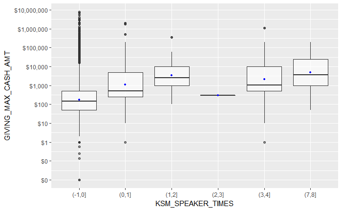

```r
full.data %>% mutate(KSM_SPEAKER_TIMES = cut(KSM_SPEAKER_TIMES, c(-1:8, 1E99))) %>%
boxplotter('KSM_SPEAKER_TIMES', data = .) +
  stat_summary(fun.y = mean, geom = 'point', size = 1, color = 'blue')
```

**Use binary indicator on `KSM_SPEAKER_YEARS` and exclude `KSM_SPEAKER_TIMES`.**

### KSM leadership committees

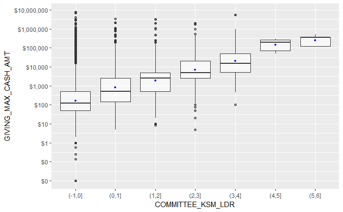

```r
full.data %>% mutate(COMMITTEE_KSM_LDR = cut(COMMITTEE_KSM_LDR, c(-1:6, 1E99))) %>%
boxplotter('COMMITTEE_KSM_LDR', data = .) +
  stat_summary(fun.y = mean, geom = 'point', size = 1, color = 'blue')
```

Seems fine to leave as is.

### KSM Reunion attendance

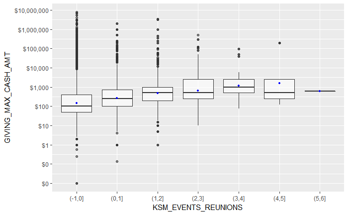

```r
full.data %>% mutate(KSM_EVENTS_REUNIONS = cut(KSM_EVENTS_REUNIONS, c(-1:6, 1E99))) %>%
boxplotter('KSM_EVENTS_REUNIONS', data = .) +
  stat_summary(fun.y = mean, geom = 'point', size = 1, color = 'blue')
```

**Split `KSM_EVENTS_REUNIONS` into 0, 1, 2, 3+.**

### Featured communication years count

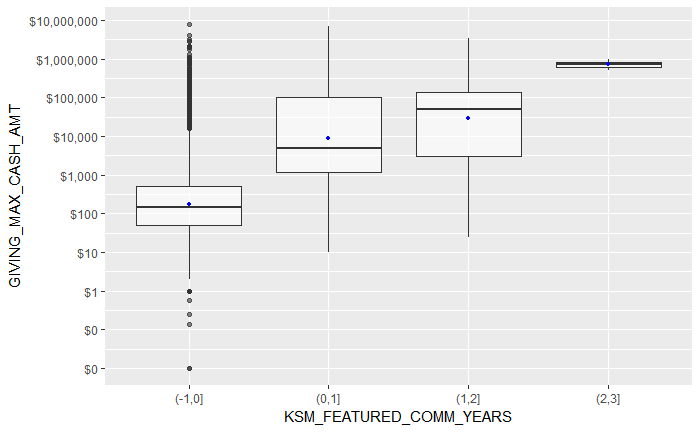

```r
full.data %>% mutate(KSM_FEATURED_COMM_YEARS = cut(KSM_FEATURED_COMM_YEARS, c(-1:3, 1E99))) %>%
boxplotter('KSM_FEATURED_COMM_YEARS', data = .) +
  stat_summary(fun.y = mean, geom = 'point', size = 1, color = 'blue')
```

This is somewhat problematic because people are often featured because they gave. Might as well try it though. **Treat `KSM_FEATURED_COMM_YEARS` as binary.**

GIFT_CLUB_LOYAL_YRS - how many per lvl GIFT_CLUB_NU_LDR_YRS - same VISITS - does it look better on sqrt or log scale VISITORS_PFY1-5 - try combining multi years of counts GIVING_MAX_CASH_AMT - piecewise linear?

# Data file cleanup goals

- R script to clean data file for processing
- Written as a function taking data file path as an argument

This is implemented in `parse_data.R`.